# 02 – Rerun MIIC on the authors’ input (case study 1)

Same input files, same settings: do we get the same network?

Author

Minh Le, Jeanne Leclerc

Published

October 6, 2026

## Goal

Notebook 01 described the files the authors uploaded to the CausalCCC web server and the network it returned. Here we run MIIC ourselves, on our computer, with the **same three input files** and the **same settings**, and compare our network with theirs. This is the most basic reproducibility test: if it fails, there is no point rebuilding the input files from the public data.

Three things can make our result differ even if everything is done correctly:

1. **Code version.** We use `miic` from the `causalccc` branch, commit `5ca0b22`, dated 23 January 2025. The authors’ server job ran on 21 January 2025, two days earlier, so the server cannot have used exactly this commit.
2. **Randomness.** The confidence filter compares each link with 100 randomly shuffled versions of the data. Different random shuffles give slightly different confidence values, so links close to the threshold can be kept in one run and removed in another. We fix the random seed so that *our* run is repeatable, but we cannot know the server’s seed.
3. **Number of threads.** The server used 2. This should not change the result, but we keep 2 to stay close.

**Inputs:** the authors’ files in `data/case1/causalccc_server_eaP9Br0llvzxN07zZZEC/` (read only). **Outputs:** `results/02_rerun_miic/`: the full MIIC result (`miic_result.rds`) and our edge list (`edges_rerun.tsv`).

**Running time**

## Setup

Besides the tidyverse we load `miic`. Loading it prints a few warnings such as “replacing previous import ‘data.table::first’ by ‘dplyr::first’”: two of the packages `miic` uses define functions with the same name, and R tells us which one wins. They are harmless.

```r
library(tidyverse)
library(miic)
find_repo_root <- function(dir = getwd()) {
  # The repository root is the folder that contains both README.md and notebooks/
  while (!(file.exists(file.path(dir, "README.md")) && dir.exists(file.path(dir, "notebooks")))) {
    parent <- dirname(dir)
    if (parent == dir) stop("Repository root not found. Open the repository folder in Positron.")
    dir <- parent
  }
  dir
}

root        <- find_repo_root()
job_dir     <- file.path(root, "data", "case1", "causalccc_server_eaP9Br0llvzxN07zZZEC")
results_dir <- file.path(root, "results", "02_rerun_miic")

if (!dir.exists(job_dir)) stop("Data not found: run scripts/download_case1.sh first.")
dir.create(results_dir, recursive = TRUE, showWarnings = FALSE)

# Which miic are we using? It should be the causalccc branch, version 2.0.x.
packageVersion("miic")
```

```
[1] '2.0.3'
```

## 1. Read the inputs

We read the three files the server used. `miic()` expects classic R data frames, so we convert the tibbles with `as.data.frame()`, which keeps column names such as `H2-D1_senders` unchanged. The L-R table must have columns named exactly `ligand` and `receptor`, because that is how `miic` looks them up.

```r
mosaic      <- read_tsv(file.path(job_dir, "input.tsv"), show_col_types = FALSE)
state_order <- read_tsv(file.path(job_dir, "clean_state_order.tsv"), show_col_types = FALSE)
lr_pairs    <- read_tsv(file.path(job_dir, "clean_interact_edges.tsv"),
                        col_names = c("ligand", "receptor"), show_col_types = FALSE)

# The authors' network, to compare with ours
edges_authors <- read_tsv(file.path(job_dir, "edgesList.miic.summary.txt_save"), show_col_types = FALSE)
```

## 2. Translate the server settings into `miic()` arguments

The server log (notebook 01, section 2) gives the options it used. Each one corresponds to an argument of `miic()`; the explanations below come from the `miic` documentation (`?miic`).

| Server option | `miic()` argument | Meaning |
| --- | --- | --- |
| `-i` | `input_data` | the mosaic table |
| `-s` | `state_order` | type and group of each variable |
| `--interact-edges` | `interact_edges` | the L-R pairs, which are kept whatever the data say |
| `--complexity nml` | `cplx = "nml"` | how mutual information is corrected for the finite number of cells (the default) |
| `--orientation` | `orientation = TRUE` | orient edges when the data allow it (the default) |
| `-l orientation` | `latent = "orientation"` | allow hidden common causes (bidirected edges) when orienting (the default) |
| `--orient_probab_ratio 0.01` | `ori_proba_ratio = 0.01` | accept an arrowhead only if (1 − p) / p < 0.01, i.e. p > 0.99. **The default is 1**, which accepts all orientations |
| `--conf_shuffle 100` | `n_shuffles = 100` | number of shuffled datasets for the confidence filter (default 0: no filter) |
| `--conf_ratio 0.01` | `conf_threshold = 0.01` | remove links whose confidence ratio is above 0.01 (default 0: no filter) |
| `--test_MAR` | `test_mar = TRUE` | check that missing values do not bias conditional tests (the default) |
| `--consistency no` | `consistent = "no"` | no extra consistency step (the default) |
| `-e -1` | `n_eff = -1` | cells are treated as independent samples (the default) |
| `--miic_mode S` | `mode = "S"` | standard mode, not temporal (the default) |
| `--n_threads 2` | `n_threads = 2` | number of processor cores used |
| `--max_nodes 200` | (not needed) | only used in temporal mode |
| `--plots` | (not needed) | server-side drawings |

Three settings differ from the defaults (`ori_proba_ratio`, `n_shuffles`, `conf_threshold`): forgetting them would give a different network. We still write every argument explicitly, so that the call documents itself.

## 3. Run MIIC (or reload the saved result)

`set.seed()` fixes R’s random number generator. MIIC draws the random shuffles of the confidence filter from it, so the same seed gives the same shuffles and therefore the same result every time we run this notebook.

The `if` block runs MIIC only when no saved result exists; otherwise it reads the saved one with `readRDS()`. While it runs, `miic` prints one line “Did not remove … edge” for each of the 18 L-R pairs: this is the branch confirming that it keeps them.

```r
result_file <- file.path(results_dir, "miic_result.rds")

if (file.exists(result_file)) {
  miic_result <- readRDS(result_file)
  message("Loaded the saved result from ", result_file)
} else {
  set.seed(2026)
  start <- Sys.time()
  miic_result <- miic(
    input_data      = as.data.frame(mosaic),
    state_order     = as.data.frame(state_order),
    interact_edges  = as.data.frame(lr_pairs),
    cplx            = "nml",
    orientation     = TRUE,
    latent          = "orientation",
    ori_proba_ratio = 0.01,
    n_shuffles      = 100,
    conf_threshold  = 0.01,
    test_mar        = TRUE,
    consistent      = "no",
    n_eff           = -1,
    mode            = "S",
    n_threads       = 2
  )
  attr(miic_result, "run_time") <- Sys.time() - start   # keep the running time with the result
  saveRDS(miic_result, result_file)
}
```

```
[1] "the interactEdges file is detected in miic.R"
[1] "the optional weight column in interactEdges file is not a problem in miic.reconstruct.R"
Search all pairs for unconditional independence relations...
Did not remove 1---95edge in initializeEdges() because status is 1
Did not remove 0---89edge in initializeEdges() because status is 1
Did not remove 0---90edge in initializeEdges() because status is 1
Did not remove 0---91edge in initializeEdges() because status is 1
Did not remove 0---92edge in initializeEdges() because status is 1
Did not remove 0---93edge in initializeEdges() because status is 1
Did not remove 0---94edge in initializeEdges() because status is 1
Did not remove 2---96edge in initializeEdges() because status is 1
Did not remove 3---97edge in initializeEdges() because status is 1
Did not remove 4---98edge in initializeEdges() because status is 1
Did not remove 5---89edge in initializeEdges() because status is 1
Did not remove 5---90edge in initializeEdges() because status is 1
Did not remove 5---91edge in initializeEdges() because status is 1
Did not remove 5---92edge in initializeEdges() because status is 1
Did not remove 5---93edge in initializeEdges() because status is 1
Did not remove 5---94edge in initializeEdges() because status is 1
Did not remove 6---95edge in initializeEdges() because status is 1
Did not remove 7---97edge in initializeEdges() because status is 1
Search for candidate separating nodes...
Search for conditional independence relations...
Compute confidence cut with permutations...51 edges cut.
Search for edge directions...
Number of edges: 346
```

```r
attr(miic_result, "run_time")
```

```
Time difference of 8.065433 mins
```

`miic()` returns a list of several tables. The one we need is `all.edges.summary`: one row per pair of genes examined, with the same columns as the authors’ file plus two extra ones (`raw_contributions`, `contributions`).

```r
names(miic_result)
```

```
[1] "adj_matrix"        "proba_adj_matrix"  "edges"
[4] "orientations.prob" "time"              "interrupted"
[7] "all.edges.summary" "params"            "state_order"
```

```r
edges_ours_raw <- as_tibble(miic_result$all.edges.summary)

# Same columns as the authors' file?
setdiff(names(edges_authors), names(edges_ours_raw))   # columns only the authors have
```

```
character(0)
```

```r
setdiff(names(edges_ours_raw), names(edges_authors))   # columns only we have
```

```
[1] "raw_contributions" "contributions"
```

```r
# Same number of rows?
tibble(edge_list = c("authors", "ours"), rows = c(nrow(edges_authors), nrow(edges_ours_raw)))
```

```
# A tibble: 2 × 2
  edge_list  rows
  <chr>     <int>
1 authors    3798
2 ours       3816
```

## 4. A first difference: the L-R pairs are listed twice

Our edge list has 18 more rows than the authors’. To compare links, we need a name for each link that does not depend on which gene is written as `x` and which as `y`: we use the two gene names sorted alphabetically (`pmin()` and `pmax()` return the “smaller” and the “larger” of two texts). Then we look at the rows of the L-R pairs in both files.

```r
link_name <- function(a, b) paste(pmin(a, b), pmax(a, b), sep = " | ")

lr_links <- link_name(lr_pairs$ligand, lr_pairs$receptor)

edges_ours_raw |>
  filter(link_name(x, y) %in% lr_links) |>
  select(x, y, type, info_shifted, Nxy_ai, infOrt, proba) |>
  arrange(link_name(x, y)) |>
  head(6)
```

```
# A tibble: 6 × 7
  x             y             type  info_shifted Nxy_ai infOrt proba
  <chr>         <chr>         <chr>        <dbl>  <dbl>  <dbl> <chr>
1 Cd28          Cd86_senders  P               0       0      1 0.5;0.5
2 Cd86_senders  Cd28          P            1083.     NA      2 0.5;1
3 Cd8a          H2-D1_senders P               0       0      1 0.5;0.5
4 H2-D1_senders Cd8a          P            1083.     NA      2 0.5;1
5 Cd8a          H2-K1_senders P               0       0      1 0.5;0.5
6 H2-K1_senders Cd8a          P            1083.     NA      2 0.5;1
```

```r
# How many rows per L-R pair in each file?
tibble(edge_list = c("authors", "ours"),
       rows_for_LR_pairs = c(sum(link_name(edges_authors$x, edges_authors$y) %in% lr_links),
                             sum(link_name(edges_ours_raw$x, edges_ours_raw$y) %in% lr_links)))
```

```
# A tibble: 2 × 2
  edge_list rows_for_LR_pairs
  <chr>                 <int>
1 authors                  18
2 ours                     36
```

Each L-R pair appears twice in our result:

- a **placeholder row** written by the C++ core, which forces the pair into the network: strength 0, computed on 0 cells (`Nxy_ai = 0`, because no cell has both a sender and a receiver value), not oriented;
- the **row added at the end** by the `causalccc` branch: strength set to the network’s maximum, oriented ligand → receptor (`proba = 0.5;1`).

The authors’ file contains only the second kind, so the code that ran on the server (two days older than ours) did not keep the placeholder rows. They carry no information, so we remove them before comparing: a row is a placeholder if it belongs to an L-R pair and was computed on 0 cells. (`%in%` is used rather than `==` because `Nxy_ai` is `NA` on the added rows, and `NA == 0` is `NA`, not `FALSE`.)

We save the cleaned edge list as a text file, so that it can be opened without R and reused in later notebooks.

```r
edges_ours <- edges_ours_raw |>
  filter(!(link_name(x, y) %in% lr_links & Nxy_ai %in% 0))

nrow(edges_ours)
```

```
[1] 3798
```

```r
write_tsv(edges_ours, file.path(results_dir, "edges_rerun.tsv"))
```

## 5. Compare the two networks

**Every pair examined.** MIIC examined 3,798 pairs of genes and decided for each whether to keep the link (`P`) or not (`N`). We first check that both runs took the same decision for every pair, and compare the values computed along the way: `info` (mutual information), `confidence` (the result of the random shuffles) and `proba` (orientation probabilities).

```r
all_pairs <- inner_join(
  edges_authors |> transmute(link = link_name(x, y), type, info, confidence, proba),
  edges_ours    |> transmute(link = link_name(x, y), type, info, confidence, proba),
  by = "link", suffix = c("_authors", "_ours"))

# Counts of pairs
tibble(
  check = c("pairs found in both edge lists",
            "pairs with the same decision (P or N)",
            "pairs with the same orientation probabilities"),
  pairs = c(nrow(all_pairs),
            sum(all_pairs$type_authors == all_pairs$type_ours),
            sum(all_pairs$proba_authors == all_pairs$proba_ours, na.rm = TRUE))
)
```

```
# A tibble: 3 × 2
  check                                         pairs
  <chr>                                         <int>
1 pairs found in both edge lists                 3798
2 pairs with the same decision (P or N)          3798
3 pairs with the same orientation probabilities  3798
```

```r
# Largest differences between the two runs
tibble(
  value = c("mutual information (info)", "confidence ratio"),
  largest_difference = c(max(abs(all_pairs$info_authors - all_pairs$info_ours), na.rm = TRUE),
                         max(abs(all_pairs$confidence_authors - all_pairs$confidence_ours), na.rm = TRUE))
)
```

```
# A tibble: 2 × 2
  value                     largest_difference
  <chr>                                  <dbl>
1 mutual information (info)           1.78e-15
2 confidence ratio                    2.71e- 4
```

**Retained links in a common format.** From now on we keep only the retained links. The orientation code `infOrt` refers to x and y, so when our link name puts the genes in the other order, the code must follow: 2 (x → y) becomes −2, while 1 (not oriented) and 6 (bidirected) stay the same.

```r
standardise <- function(edge_list) {
  edge_list |>
    filter(type == "P") |>                      # retained links only
    mutate(first  = pmin(x, y),
           second = pmax(x, y),
           link   = link_name(x, y),
           # orientation from `first` to `second`: 2 = first -> second, -2 = second -> first
           orientation = if_else(x == first | infOrt %in% c(1, 6), infOrt, -infOrt),
           category = case_when(
             str_detect(first, "_senders$") & str_detect(second, "_senders$")   ~ "within senders",
             !str_detect(first, "_senders$") & !str_detect(second, "_senders$") ~ "within receivers",
             .default = "ligand-receptor")) |>
    select(link, first, second, category, orientation, is_causal, info_shifted, confidence)
}

links_authors <- standardise(edges_authors)
links_ours    <- standardise(edges_ours)

tibble(network = c("authors", "ours"),
       links   = c(nrow(links_authors), nrow(links_ours)))
```

```
# A tibble: 2 × 2
  network links
  <chr>   <int>
1 authors   364
2 ours      364
```

**Which links are shared?** `full_join()` puts the two tables side by side, matching rows on the link name, and keeps links found in only one of them (with `NA` on the other side). The suffixes `_authors` and `_ours` tell the two versions of each column apart.

```r
comparison <- full_join(links_authors, links_ours,
                        by = c("link", "first", "second", "category"),
                        suffix = c("_authors", "_ours")) |>
  mutate(found_in = case_when(!is.na(orientation_authors) & !is.na(orientation_ours) ~ "both",
                              !is.na(orientation_authors) ~ "authors only",
                              .default = "ours only"))

count(comparison, category, found_in)
```

```
# A tibble: 3 × 3
  category         found_in     n
  <chr>            <chr>    <int>
1 ligand-receptor  both        18
2 within receivers both       218
3 within senders   both       128
```

The Jaccard index summarises the overlap in one number: shared links divided by all distinct links. It is 1 when the two networks have exactly the same links and 0 when they share none.

```r
mean(comparison$found_in == "both")
```

```
[1] 1
```

**Links found in only one network.** If there were any, we would want to know why. Links that come from randomness in the confidence filter should have a confidence ratio close to the 0.01 threshold, so we look them up in both complete edge lists (including rejected links). An empty table (`0 x 8`) means there is no such link.

```r
lookup <- function(edge_list) {
  edge_list |>
    mutate(link = link_name(x, y)) |>
    select(link, type, confidence, info_shifted)
}

comparison |>
  filter(found_in != "both") |>
  select(link, found_in) |>
  left_join(lookup(edges_authors), by = "link") |>
  left_join(lookup(edges_ours), by = "link", suffix = c("_authors", "_ours")) |>
  arrange(found_in, link)
```

```
# A tibble: 0 × 8
# ℹ 8 variables: link <chr>, found_in <chr>, type_authors <chr>,
#   confidence_authors <dbl>, info_shifted_authors <dbl>, type_ours <chr>,
#   confidence_ours <dbl>, info_shifted_ours <dbl>
```

**Strength of shared links.** `info_shifted` is the strength of a link (mutual information corrected for the number of cells). For links found by both runs, we compare the two values. Identical code and data should give identical values; we plot them and compute the largest difference.

```r
shared <- comparison |> filter(found_in == "both", category != "ligand-receptor")

shared |>
  summarise(links = n(),
            largest_difference = max(abs(info_shifted_authors - info_shifted_ours)),
            correlation        = cor(info_shifted_authors, info_shifted_ours))
```

```
# A tibble: 1 × 3
  links largest_difference correlation
  <int>              <dbl>       <dbl>
1   346           5.68e-14           1
```

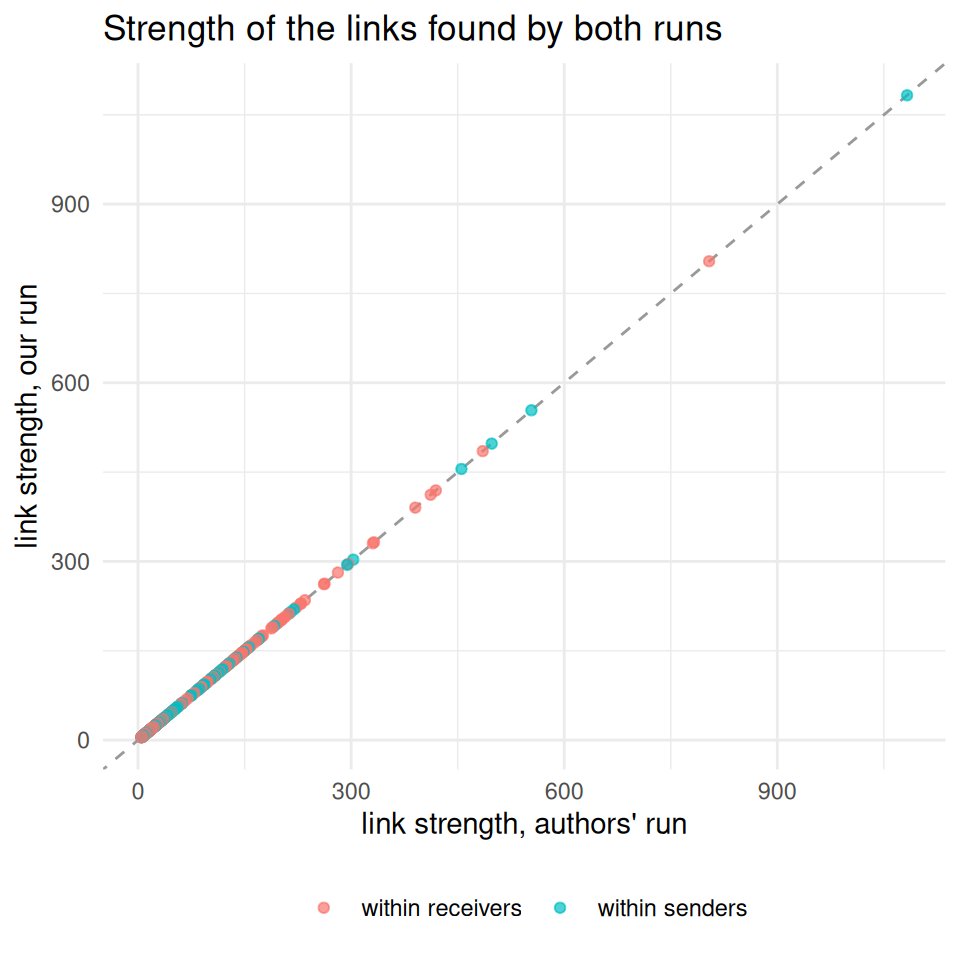

```r
ggplot(shared, aes(x = info_shifted_authors, y = info_shifted_ours, colour = category)) +
  geom_abline(linetype = "dashed", colour = "grey60") +
  geom_point(alpha = 0.7) +
  labs(x = "link strength, authors' run", y = "link strength, our run", colour = NULL,
       title = "Strength of the links found by both runs") +
  theme_minimal() +
  theme(legend.position = "bottom")
```

**Orientations of shared links.** We cross-tabulate the orientation found by each run, using the codes of the common format (1 = not oriented, 2 = first → second, −2 = second → first, 6 = bidirected). Everything on the diagonal agrees.

```r
shared_all <- comparison |> filter(found_in == "both")

table(authors = shared_all$orientation_authors, ours = shared_all$orientation_ours)
```

```
       ours
authors  -2   1   2   6
     -2  41   0   0   0
     1    0 270   0   0
     2    0   0  48   0
     6    0   0   0   5
```

```r
# Genuine causation ("Y") in each run
table(authors = shared_all$is_causal_authors, ours = shared_all$is_causal_ours)
```

```
       ours
authors   N   Y
      N 351   0
      Y   0  13
```

## 6. The L-R links in the two versions of the authors’ file

`miic` does not compute the 18 L-R links: the `causalccc` branch adds them at the end, with a strength equal to the strongest link of the network (code in `R/parseResults.R` of the branch). We check that our run and the authors’ January file give them the same strength, and look at what the April edit changed. For comparison, we also print the two largest values found among the gene–gene links.

```r
edges_april <- read_tsv(file.path(job_dir, "edgesList.miic.summary.txt"), show_col_types = FALSE)

lr_values <- function(edge_list, version) {
  edge_list |>
    filter(link_name(x, y) %in% lr_links) |>   # keep only the 18 L-R rows
    transmute(ligand = x, receptor = y, strength = info_shifted, version = version)
}

bind_rows(lr_values(edges_ours, "ours"),
          lr_values(edges_authors, "authors, January"),
          lr_values(edges_april, "authors, April")) |>
  pivot_wider(names_from = version, values_from = strength)
```

```
# A tibble: 18 × 5
   ligand         receptor  ours `authors, January` `authors, April`
   <chr>          <chr>    <dbl>              <dbl>            <dbl>
 1 H2-D1_senders  Cd8a     1083.              1083.           1208.
 2 H2-K1_senders  Cd8a     1083.              1083.           1208.
 3 H2-M3_senders  Cd8a     1083.              1083.           1208.
 4 H2-Q4_senders  Cd8a     1083.              1083.           1208.
 5 H2-Q6_senders  Cd8a     1083.              1083.           1208.
 6 H2-Q7_senders  Cd8a     1083.              1083.           1208.
 7 Tgfb1_senders  Tgfbr2   1083.              1083.           1100.
 8 Sell_senders   Selplg   1083.              1083.           1023.
 9 Cxcl10_senders Cxcr3    1083.              1083.            993.
10 Cd86_senders   Cd28     1083.              1083.            931.
11 H2-M3_senders  Klrd1    1083.              1083.            361.
12 H2-D1_senders  Klrd1    1083.              1083.            361.
13 H2-K1_senders  Klrd1    1083.              1083.            361.
14 H2-Q4_senders  Klrd1    1083.              1083.            361.
15 H2-Q6_senders  Klrd1    1083.              1083.            361.
16 H2-Q7_senders  Klrd1    1083.              1083.            361.
17 Tgfb1_senders  Itgb1    1083.              1083.             21.9
18 Cxcl10_senders Dpp4     1083.              1083.              6.5
```

```r
# The strongest gene-gene link, measured in two ways
edges_ours |>
  filter(type == "P", !link_name(x, y) %in% lr_links) |>
  summarise(max_info_shifted = max(info_shifted), max_info = max(info))
```

```
# A tibble: 1 × 2
  max_info_shifted max_info
             <dbl>    <dbl>
1            1083.    1208.
```

Our run and the January file agree: every L-R link gets the same strength, equal to the largest `info_shifted` of the network. In the April version, every link to the same receptor shares one value, and the values differ between receptors: the largest `info` of the network for Cd8a, much lower values for Klrd1, and only single digits for Dpp4. Neither the paper nor the tutorial says where these values come from. Since Figure 2 draws L-R edge thickness from such values, it was probably made from the April version: a question for the authors.

## 7. A note on two columns

**`proba`.** The `miic` documentation describes this column as “p(x->y);p(x<-y)”. The code that writes it (`R/parseResults.R`, lines 184 and 231–232 of the branch) shows that the first number is the probability of an arrowhead **on the x side** and the second the probability of an arrowhead **on the y side**. Example: for x = B2m and y = Stat1, `proba = 0.99999;0.00015` means an arrowhead at B2m and not at Stat1, that is Stat1 → B2m, in agreement with `infOrt = −2`.

**Why Tgfb1 is discrete** (question from notebook 01). The `causalCCC` package declares a variable discrete when it has 5 or fewer distinct values, and its function `causalCCC.state_order()` counts `NA` as one of them (it uses `n_distinct()` without `na.rm = TRUE`). In sender cells Tgfb1 takes 4 count values, plus `NA` from the receiver rows: 5 in total, hence discrete. It is the only variable in this situation:

```r
distinct_with_na <- map_int(mosaic, n_distinct)   # NA counted as a value, as in causalCCC
names(distinct_with_na)[distinct_with_na <= 5]
```

```
[1] "Tgfb1_senders"
```

## 8. Do the paper’s statements still hold in our network?

Notebook 01 checked the authors’ network. We repeat the two sharpest checks on ours: the neighbours of the H2 ligands, and the Stat1 → B2m genuine causation.

```r
network_ours <- edges_ours |> filter(type == "P")

h2_ligands <- unique(str_subset(lr_pairs$ligand, "^H2-"))
claimed    <- paste0(c("Psmb8", "Ifi27l2b", "Slfn1", "Shisa5", "Irf7", "Mir703", "B2m"), "_senders")

h2_neighbors <- network_ours |>
  filter(x %in% h2_ligands | y %in% h2_ligands) |>
  transmute(neighbor = if_else(x %in% h2_ligands, y, x))

tibble(gene = claimed, neighbor_of_an_H2_ligand = claimed %in% h2_neighbors$neighbor)
```

```
# A tibble: 7 × 2
  gene             neighbor_of_an_H2_ligand
  <chr>            <lgl>
1 Psmb8_senders    TRUE
2 Ifi27l2b_senders TRUE
3 Slfn1_senders    TRUE
4 Shisa5_senders   TRUE
5 Irf7_senders     TRUE
6 Mir703_senders   TRUE
7 B2m_senders      TRUE
```

```r
network_ours |>
  filter(x %in% c("Stat1_senders", "B2m_senders"), y %in% c("Stat1_senders", "B2m_senders")) |>
  select(x, y, infOrt, is_causal, proba)
```

```
# A tibble: 1 × 5
  x           y             infOrt is_causal proba
  <chr>       <chr>          <dbl> <chr>     <chr>
1 B2m_senders Stat1_senders     -2 Y         0.999999995470155;0.00015363728681…
```

## What we learned

**The network is reproduced.** With the authors’ three input files and the server’s settings translated into `miic()` arguments, our run gives the same network as the server:

- the same decision (kept or rejected) for all 3,798 gene pairs examined;
- the same 364 retained links: 128 within CD4+ senders, 218 within CD8+ receivers, and the 18 L-R links;
- identical link strengths and orientation probabilities (differences around 10⁻¹⁴, rounding noise);
- identical orientations and the same 13 genuine causations;
- confidence ratios very slightly different (random shuffles with a different seed), with no effect on any decision.

The paper’s statements checked in notebook 01 therefore hold for our run too.

**One difference in bookkeeping.** Our version of `miic` lists each L-R pair twice: a placeholder row (strength 0, not oriented) and the row added at the end. The server’s version, two days older, only kept the second. We remove the placeholders; anyone reusing this branch should do the same, otherwise the L-R links are counted twice and appear unoriented.

**What this means for the project.** The computational step is reproducible. Remaining differences between the published result and a rebuilt analysis can only come from upstream: the preparation of the input files from the public data (cell and gene selection, L-R pairs), which notebooks 03 to 05 rebuild.

**Points to note or ask the authors.**

- The `miic` documentation describes the `proba` column in the wrong order (section 7).
- `causalCCC.state_order()` counts `NA` as a value when deciding whether a variable is discrete. In a mosaic table every variable has `NA`, so the effective rule is “4 or fewer observed values”. This made Tgfb1 discrete in sender cells but continuous in receiver cells, where it takes one more value. Is that intended?
- The April edit of the edge list gave the L-R links per-receptor strengths whose origin is not documented (section 6).